# Differentiating Purpose and Happiness: Evidence from Personal Strivings, Daily Goal Pursuit, and Responses to Life Adversity

Authors

Affiliations

Todd B. Kashdan

George Mason University

Patrick E. McKnight

George Mason University

James C. Kaufman

University of Connecticut

Abstract

Purpose in life and subjective happiness are correlated strongly enough (r = .40) that they are often treated as interchangeable. We tested whether they predict different outcomes across three assessment contexts in a 3-wave longitudinal study (N = 345 over 2 years) – personal strivings, daily goal pursuit assessed with the Day Reconstruction Method, and responses to stressful life events from semi-structured interviews. The two constructs predicted different things rather than one dominating. Purpose was the stronger unique predictor of personal striving outcomes – effort, pursuit of purpose-aligned strivings, and overall engagement (7 of 8 outcomes versus 2 for happiness after controlling for the other construct). Happiness was the stronger unique predictor of daily goal-pursuit episodes and coping-strategy use, domains saturated with momentary affect. For stress-related growth at 2-year follow-up the two were comparable (purpose partial r = .19, happiness .15). Across 50 outcomes, formal tests of differential prediction reached significance for only 3. Purpose and happiness are not interchangeable, but neither is uniformly the better predictor; each carries unique information in a different domain.

Keywords

purpose in life, subjective happiness, personal strivings, emotion regulation, stress-related growth, day reconstruction method

# Setup

**Show R code**

```r
# ── Core packages ──
# Load psych FIRST to avoid select() masking dplyr
library(psych)
library(tidyverse)   # dplyr::select loaded AFTER psych
library(ppcor)
library(mice)        # Multiple imputation
library(knitr)
library(kableExtra)

# Resolve namespace conflicts explicitly
select <- dplyr::select

# ── Load data ──
dat <- read.csv(gzfile("alldatPvH4LLM.csv.gz"))

# ── Define IVs (already POMP scored 0-100) ──
dat$purpose  <- dat$b_bpurp_mean_POMP
dat$happiness <- dat$b_shs_mean_POMP

cat("Total N:", nrow(dat), "\n")
```

```
Total N: 345
```

**Show R code**

```r
cat("N with both IVs:", sum(complete.cases(dat[, c("purpose", "happiness")])), "\n")
```

```
N with both IVs: 314
```

**Show R code**

```r
# ══════════════════════════════════════════════════════════════════
# POMP TRANSFORMATION UTILITY
# ══════════════════════════════════════════════════════════════════
# POMP = (observed - min_possible) / (max_possible - min_possible) * 100
# All analyses use POMP (0-100) for cross-measure comparability

pomp <- function(x, min_possible, max_possible) {
  (x - min_possible) / (max_possible - min_possible) * 100
}

# ══════════════════════════════════════════════════════════════════
# 1. DRM EPISODE AVERAGES
# ══════════════════════════════════════════════════════════════════
# Goal pursuit items (Striv_1 through Striv_10 per episode)
# Mapping from Table 5 of Kashdan et al.:
#   1=Difficulty, 2=Competence, 3=Effort, 4=Distress, 5=Joy,
#   6=Meaning, 7=Control, 8=Values-consistency, 9=Progress, 10=Autonomy

drm_goal_labels <- c("Difficulty", "Competence", "Effort", "Distress",
                      "Joy", "Meaning", "Control", "Values_consistency",
                      "Progress", "Autonomy")

# Average POMP scores across 5 episodes per goal item
for (i in 1:10) {
  ep_cols <- paste0("Striv_", i, "_POMP_E", 1:5)
  available <- ep_cols[ep_cols %in% names(dat)]
  if (length(available) > 0) {
    dat[[paste0("DRM_goal_", drm_goal_labels[i])]] <-
      rowMeans(dat[, available, drop = FALSE], na.rm = TRUE)
  }
}

# Average positive and negative affect across episodes (already POMP)
pa_cols <- paste0("Avg_PA_DRM_POMP_E", 1:5)
na_cols <- paste0("Avg_NA_DRM_POMP_E", 1:5)
dat$DRM_PA_avg <- rowMeans(dat[, pa_cols[pa_cols %in% names(dat)], drop = FALSE], na.rm = TRUE)
dat$DRM_NA_avg <- rowMeans(dat[, na_cols[na_cols %in% names(dat)], drop = FALSE], na.rm = TRUE)

# ══════════════════════════════════════════════════════════════════
# 2. STRIVING OUTCOMES (fu1 assessment, already POMP where labeled)
# ══════════════════════════════════════════════════════════════════
# POMP versions exist: *_POMP (0-100 scale)
# TOT_STRIVIMPACT remains on -2 to +2 scale (harmony index)
# POMP-transform it: min=-2, max=+2
dat$TOT_STRIVIMPACT_POMP <- pomp(dat$TOT_STRIVIMPACT, -2, 2)

# ══════════════════════════════════════════════════════════════════
# 3. REGULATORY FLEXIBILITY INDEX
# ══════════════════════════════════════════════════════════════════
# Coping strategies: 0=did not use, 1=sometimes, 2=frequently
# POMP transform individual coping averages: min=0, max=2

coping_avg_vars <- c("Gratitude_Avg", "Humor_Avg", "ExpSupp_Avg", "CogAvoid_Avg",
                      "SubUse_Avg", "NonJudg_Avg", "EmoRum_Avg", "Religion_Avg",
                      "SeekSupport_Avg", "GiveSupport_Avg", "Exercise_Avg",
                      "CogReapp_Avg", "Distract_Avg", "PosAffirm_Avg")

# POMP-transform each coping strategy average
for (v in coping_avg_vars) {
  if (v %in% names(dat)) {
    dat[[paste0(v, "_POMP")]] <- pomp(dat[[v]], 0, 2)
  }
}

strategy_names <- c("Gratitude", "Humor", "ExpSupp", "CogAvoid", "SubUse",
                     "NonJudg", "EmoRum", "Religion", "SeekSupport",
                     "GiveSupport", "Exercise", "CogReapp", "Distract", "PosAffirm")

# Component 1: Strategy Repertoire Breadth (count of strategies used > 0)
if (all(coping_avg_vars %in% names(dat))) {
  coping_mat <- dat[, coping_avg_vars]
  dat$reg_flex_breadth <- rowSums(coping_mat > 0, na.rm = TRUE)
}

# Component 2: Context Sensitivity (within-person SD across events)
strategy_sd_mat <- matrix(NA, nrow = nrow(dat), ncol = length(strategy_names))
for (s in seq_along(strategy_names)) {
  event_cols <- paste0(strategy_names[s], "_", 1:5)
  available <- event_cols[event_cols %in% names(dat)]
  if (length(available) >= 2) {
    strategy_sd_mat[, s] <- apply(dat[, available, drop = FALSE], 1, sd, na.rm = TRUE)
  }
}
dat$reg_flex_sensitivity <- rowMeans(strategy_sd_mat, na.rm = TRUE)

# Composite: standardize and average both components
dat$reg_flex_composite <- rowMeans(
  cbind(scale(dat$reg_flex_breadth)[,1],
        scale(dat$reg_flex_sensitivity)[,1]),
  na.rm = TRUE
)

# ══════════════════════════════════════════════════════════════════
# 4. PTG COMPOSITE (2-year follow-up)
# ══════════════════════════════════════════════════════════════════
# Items scored 1-6; POMP: min=1, max=6
ptg_vars <- names(dat)[grepl("ptg_[1-5]$", names(dat))]
if (length(ptg_vars) > 0) {
  dat$PTG_composite <- rowMeans(dat[, ptg_vars, drop = FALSE], na.rm = TRUE)
  dat$PTG_composite_POMP <- pomp(dat$PTG_composite, 1, 6)
}

# ══════════════════════════════════════════════════════════════════
# 5. LIFE EVENT STRESS / COPING COMPOSITES
# ══════════════════════════════════════════════════════════════════
# Items scored 0-4; POMP: min=0, max=4

# FU1
fu1_ple_stress_vars  <- names(dat)[grepl("^fu1_ple[0-9]_1$", names(dat))]
fu1_ple_deal_vars    <- names(dat)[grepl("^fu1_ple[0-9]_2$", names(dat))]
fu1_ple_control_vars <- names(dat)[grepl("^fu1_ple[0-9]_3$", names(dat))]
fu1_ple_impair_vars  <- names(dat)[grepl("^fu1_ple[0-9]_[4-8]$", names(dat))]

dat$fu1_LE_stress     <- rowMeans(dat[, fu1_ple_stress_vars, drop = FALSE], na.rm = TRUE)
dat$fu1_LE_coping     <- rowMeans(dat[, c(fu1_ple_deal_vars, fu1_ple_control_vars), drop = FALSE], na.rm = TRUE)
dat$fu1_LE_impairment <- rowMeans(dat[, fu1_ple_impair_vars, drop = FALSE], na.rm = TRUE)

dat$fu1_LE_stress_POMP     <- pomp(dat$fu1_LE_stress, 0, 4)
dat$fu1_LE_coping_POMP     <- pomp(dat$fu1_LE_coping, 0, 4)
dat$fu1_LE_impairment_POMP <- pomp(dat$fu1_LE_impairment, 0, 4)

# FU2
fu2_ple_stress_vars  <- names(dat)[grepl("^fu2_ple[0-9]_1$", names(dat))]
fu2_ple_deal_vars    <- names(dat)[grepl("^fu2_ple[0-9]_2$", names(dat))]
fu2_ple_control_vars <- names(dat)[grepl("^fu2_ple[0-9]_3$", names(dat))]
fu2_ple_impair_vars  <- names(dat)[grepl("^fu2_ple[0-9]_[4-8]$", names(dat))]

dat$fu2_LE_stress     <- rowMeans(dat[, fu2_ple_stress_vars, drop = FALSE], na.rm = TRUE)
dat$fu2_LE_coping     <- rowMeans(dat[, c(fu2_ple_deal_vars, fu2_ple_control_vars), drop = FALSE], na.rm = TRUE)
dat$fu2_LE_impairment <- rowMeans(dat[, fu2_ple_impair_vars, drop = FALSE], na.rm = TRUE)

dat$fu2_LE_stress_POMP     <- pomp(dat$fu2_LE_stress, 0, 4)
dat$fu2_LE_coping_POMP     <- pomp(dat$fu2_LE_coping, 0, 4)
dat$fu2_LE_impairment_POMP <- pomp(dat$fu2_LE_impairment, 0, 4)

# ══════════════════════════════════════════════════════════════════
# 6. CREATIVITY (KDCS) - already POMP where labeled *_POMP
# ══════════════════════════════════════════════════════════════════

cat("── Derived variables created ──\n")
```

```
── Derived variables created ──
```

**Show R code**

```r
cat("Regulatory flexibility N:", sum(!is.na(dat$reg_flex_composite)), "\n")
```

```
Regulatory flexibility N: 345
```

**Show R code**

```r
cat("PTG composite N:", sum(!is.na(dat$PTG_composite_POMP)), "\n")
```

```
PTG composite N: 119
```

**Show R code**

```r
# ══════════════════════════════════════════════════════════════════
# MULTIPLE IMPUTATION (MICE with PMM)
# ══════════════════════════════════════════════════════════════════
# Data dictionary recommends: MICE, PMM, 20 imputations
# 75.4% of cases have some missing data; 95% monotone pattern
# We impute composite-level scores for the core analysis variables

# ── Select core analysis variables for imputation ──
core_vars <- c(
  # IVs
  "purpose", "happiness",
  # Striving outcomes (POMP)
  "CENTRALITY_tot_POMP", "SELFORG_tot_POMP", "LIFEAIM_tot_POMP",
  "PURPOSE_Pursuit_POMP", "EFFORT_tot_POMP", "SUCCESS_tot_POMP",
  "TOT_STRIVPURSUIT_POMP", "TOT_STRIVIMPACT_POMP",
  # DRM goal outcomes (POMP, averaged across episodes)
  paste0("DRM_goal_", drm_goal_labels),
  "DRM_PA_avg", "DRM_NA_avg",
  # Coping strategies (POMP)
  paste0(coping_avg_vars, "_POMP"),
  # Regulatory flexibility (z-scored composite; not POMP)
  "reg_flex_breadth", "reg_flex_sensitivity", "reg_flex_composite",
  # Longitudinal life events (POMP)
  "fu1_LE_stress_POMP", "fu1_LE_coping_POMP", "fu1_LE_impairment_POMP",
  "fu2_LE_stress_POMP", "fu2_LE_coping_POMP", "fu2_LE_impairment_POMP",
  # PTG (POMP)
  "PTG_composite_POMP",
  # Creativity (POMP)
  "b_kdcs_AvgRatingAllItems_POMP",
  "b_kdcs_Self_AvgRating_POMP", "b_kdcs_Scholarly_AvgRating_POMP",
  "b_kdcs_Performance_AvgRating_POMP", "b_kdcs_MechScience_AvgRating_POMP",
  "b_kdcs_Artistic_AvgRating_POMP"
)

# Keep only vars that exist in the data
core_vars <- core_vars[core_vars %in% names(dat)]
cat("Core analysis variables for imputation:", length(core_vars), "\n")
```

```
Core analysis variables for imputation: 52
```

**Show R code**

```r
# ── Run MICE ──
imp_data <- dat[, core_vars]

# Check missingness summary
miss_pct <- colMeans(is.na(imp_data)) * 100
cat("Variables with >50% missing (will rely on available cases):\n")
```

```
Variables with >50% missing (will rely on available cases):
```

**Show R code**

```r
print(sort(miss_pct[miss_pct > 50], decreasing = TRUE))
```

```
    fu2_LE_stress_POMP     fu2_LE_coping_POMP fu2_LE_impairment_POMP
              65.50725               65.50725               65.50725
    PTG_composite_POMP
              65.50725
```

**Show R code**

```r
# Run MICE: 20 imputations, PMM for continuous variables
set.seed(2024)
mice_obj <- mice(imp_data, m = 20, method = "pmm", maxit = 10,
                 printFlag = FALSE)

cat("\n── MICE complete: 20 imputations ──\n")
```

```
── MICE complete: 20 imputations ──
```

**Show R code**

```r
n_logged <- ifelse(is.null(mice_obj$loggedEvents), 0, nrow(mice_obj$loggedEvents))
cat("Logged events:", n_logged, "\n")
```

```
Logged events: 9360
```

**Show R code**

```r
# ── Pool function for correlation-based analyses on imputed data ──
# Applies analysis to each imputed dataset, pools via Rubin's rules
pool_correlation_analysis <- function(mice_obj, iv1, iv2, dv) {
  m <- mice_obj$m
  r_iv1 <- r_iv2 <- r_iv12 <- numeric(m)
  pr_iv1 <- pr_iv2 <- numeric(m)
  ns <- numeric(m)

  for (i in 1:m) {
    d <- complete(mice_obj, i)
    cc <- complete.cases(d[, c(iv1, iv2, dv)])
    dd <- d[cc, ]
    n <- nrow(dd)
    ns[i] <- n
    if (n < 10) { r_iv1[i] <- r_iv2[i] <- r_iv12[i] <- pr_iv1[i] <- pr_iv2[i] <- NA; next }

    r_iv1[i]  <- cor(dd[[iv1]], dd[[dv]])
    r_iv2[i]  <- cor(dd[[iv2]], dd[[dv]])
    r_iv12[i] <- cor(dd[[iv1]], dd[[iv2]])

    # Partial correlations
    tryCatch({
      pc1 <- pcor.test(dd[[iv1]], dd[[dv]], dd[[iv2]], method = "pearson")
      pr_iv1[i] <- pc1$estimate
      pc2 <- pcor.test(dd[[iv2]], dd[[dv]], dd[[iv1]], method = "pearson")
      pr_iv2[i] <- pc2$estimate
    }, error = function(e) { pr_iv1[i] <<- NA; pr_iv2[i] <<- NA })
  }

  # Pool via Fisher z-transform (Rubin's rules)
  z_transform <- function(r) 0.5 * log((1 + r) / (1 - r))
  z_back      <- function(z) (exp(2 * z) - 1) / (exp(2 * z) + 1)

  pool_r <- function(rs) {
    zs <- z_transform(rs[!is.na(rs)])
    if (length(zs) == 0) return(NA)
    z_back(mean(zs))
  }

  avg_n <- round(mean(ns, na.rm = TRUE))
  list(
    r_iv1  = pool_r(r_iv1),
    r_iv2  = pool_r(r_iv2),
    r_iv12 = pool_r(r_iv12),
    pr_iv1 = pool_r(pr_iv1),
    pr_iv2 = pool_r(pr_iv2),
    n      = avg_n
  )
}

# ── Master analysis function using pooled imputed estimates ──
run_mi_differential_analysis <- function(mice_obj, iv1 = "purpose",
                                          iv2 = "happiness",
                                          dv_names, dv_labels = NULL) {
  if (is.null(dv_labels)) dv_labels <- dv_names

  results <- data.frame(
    Outcome = dv_labels,
    Purpose_r = NA_real_, Purpose_p = NA_real_,
    Happiness_r = NA_real_, Happiness_p = NA_real_,
    Diff = NA_real_, Williams_t = NA_real_, Williams_p = NA_real_,
    Purpose_pr = NA_real_, Purpose_pr_p = NA_real_,
    Happiness_pr = NA_real_, Happiness_pr_p = NA_real_,
    N = NA_integer_,
    stringsAsFactors = FALSE
  )

  imp_vars <- names(complete(mice_obj, 1))

  for (i in seq_along(dv_names)) {
    dv <- dv_names[i]
    if (!dv %in% imp_vars) next

    pooled <- pool_correlation_analysis(mice_obj, iv1, iv2, dv)
    if (is.na(pooled$r_iv1)) next

    n <- pooled$n
    results$N[i] <- n
    results$Purpose_r[i]   <- pooled$r_iv1
    results$Happiness_r[i] <- pooled$r_iv2

    # P-values from pooled r (approximation using avg n)
    t_p <- pooled$r_iv1 * sqrt((n - 2) / (1 - pooled$r_iv1^2))
    t_h <- pooled$r_iv2 * sqrt((n - 2) / (1 - pooled$r_iv2^2))
    results$Purpose_p[i]   <- 2 * pt(-abs(t_p), df = n - 2)
    results$Happiness_p[i] <- 2 * pt(-abs(t_h), df = n - 2)

    # Williams' test on pooled correlations
    wt <- williams_test(pooled$r_iv1, pooled$r_iv2, pooled$r_iv12, n)
    results$Diff[i]       <- wt$diff
    results$Williams_t[i] <- wt$t
    results$Williams_p[i] <- wt$p

    # Pooled partial correlations
    results$Purpose_pr[i]   <- pooled$pr_iv1
    results$Happiness_pr[i] <- pooled$pr_iv2

    # P-values for partial r (df = n - 3 for one control variable)
    t_pr1 <- pooled$pr_iv1 * sqrt((n - 3) / (1 - pooled$pr_iv1^2))
    t_pr2 <- pooled$pr_iv2 * sqrt((n - 3) / (1 - pooled$pr_iv2^2))
    results$Purpose_pr_p[i]   <- 2 * pt(-abs(t_pr1), df = n - 3)
    results$Happiness_pr_p[i] <- 2 * pt(-abs(t_pr2), df = n - 3)
  }

  # FDR correction
  results$Purpose_p_BH      <- p.adjust(results$Purpose_p, method = "BH")
  results$Happiness_p_BH    <- p.adjust(results$Happiness_p, method = "BH")
  results$Williams_p_BH     <- p.adjust(results$Williams_p, method = "BH")
  results$Purpose_pr_p_BH   <- p.adjust(results$Purpose_pr_p, method = "BH")
  results$Happiness_pr_p_BH <- p.adjust(results$Happiness_pr_p, method = "BH")

  return(results)
}
```

**Show R code**

```r
# ══════════════════════════════════════════════════════════════════
# CORE ANALYSIS FUNCTIONS
# ══════════════════════════════════════════════════════════════════

# ── Williams' t-test for comparing dependent correlations ──
# Tests whether r(X,Z) differs from r(Y,Z) when X and Y are correlated
williams_test <- function(r_xz, r_yz, r_xy, n) {
  r_det <- 1 - r_xz^2 - r_yz^2 - r_xy^2 + 2 * r_xz * r_yz * r_xy
  t_num <- (r_xz - r_yz) * sqrt((n - 1) * (1 + r_xy))
  t_den <- sqrt(2 * ((n - 1) / (n - 3)) * r_det +
                ((r_xz + r_yz)^2 / 4) * (1 - r_xy)^3)
  t_stat <- t_num / t_den
  p_value <- 2 * pt(-abs(t_stat), df = n - 3)
  return(list(t = t_stat, p = p_value, df = n - 3, diff = r_xz - r_yz))
}

# ── Run differential correlation analysis for a set of outcomes ──
run_differential_analysis <- function(data, iv1_name = "purpose",
                                       iv2_name = "happiness",
                                       dv_names, dv_labels = NULL) {
  if (is.null(dv_labels)) dv_labels <- dv_names

  results <- data.frame(
    Outcome = dv_labels,
    Purpose_r = NA_real_, Purpose_p = NA_real_,
    Happiness_r = NA_real_, Happiness_p = NA_real_,
    Diff = NA_real_, Williams_t = NA_real_, Williams_p = NA_real_,
    Purpose_pr = NA_real_, Purpose_pr_p = NA_real_,
    Happiness_pr = NA_real_, Happiness_pr_p = NA_real_,
    N = NA_integer_,
    stringsAsFactors = FALSE
  )

  for (i in seq_along(dv_names)) {
    dv <- dv_names[i]
    if (!dv %in% names(data)) next

    complete <- complete.cases(data[, c(iv1_name, iv2_name, dv)])
    n <- sum(complete)
    if (n < 10) next

    d <- data[complete, ]
    results$N[i] <- n

    # Bivariate correlations
    r_purp  <- cor(d[[iv1_name]], d[[dv]], use = "complete.obs")
    r_happy <- cor(d[[iv2_name]], d[[dv]], use = "complete.obs")
    r_iv    <- cor(d[[iv1_name]], d[[iv2_name]], use = "complete.obs")

    results$Purpose_r[i]   <- r_purp
    results$Happiness_r[i] <- r_happy

    # P-values for bivariate correlations
    t_purp  <- r_purp * sqrt((n - 2) / (1 - r_purp^2))
    t_happy <- r_happy * sqrt((n - 2) / (1 - r_happy^2))
    results$Purpose_p[i]   <- 2 * pt(-abs(t_purp), df = n - 2)
    results$Happiness_p[i] <- 2 * pt(-abs(t_happy), df = n - 2)

    # Williams' test
    wt <- williams_test(r_purp, r_happy, r_iv, n)
    results$Diff[i]       <- wt$diff
    results$Williams_t[i] <- wt$t
    results$Williams_p[i] <- wt$p

    # Partial correlations (construct specificity)
    tryCatch({
      pc <- pcor.test(d[[iv1_name]], d[[dv]], d[[iv2_name]], method = "pearson")
      results$Purpose_pr[i]   <- pc$estimate
      results$Purpose_pr_p[i] <- pc$p.value

      pc2 <- pcor.test(d[[iv2_name]], d[[dv]], d[[iv1_name]], method = "pearson")
      results$Happiness_pr[i]   <- pc2$estimate
      results$Happiness_pr_p[i] <- pc2$p.value
    }, error = function(e) NULL)
  }

  # Apply FDR correction across all tests
  results$Purpose_p_BH   <- p.adjust(results$Purpose_p, method = "BH")
  results$Happiness_p_BH <- p.adjust(results$Happiness_p, method = "BH")
  results$Williams_p_BH  <- p.adjust(results$Williams_p, method = "BH")
  results$Purpose_pr_p_BH   <- p.adjust(results$Purpose_pr_p, method = "BH")
  results$Happiness_pr_p_BH <- p.adjust(results$Happiness_pr_p, method = "BH")

  return(results)
}

# ── Format results table for display ──
format_results_table <- function(results, caption = "") {
  sig_stars <- function(p) {
    case_when(p < 0.001 ~ "***", p < 0.01 ~ "**", p < 0.05 ~ "*", TRUE ~ "")
  }

  display <- results %>%
    filter(!is.na(Purpose_r)) %>%
    transmute(
      Outcome,
      `Purpose r`   = sprintf("%.2f%s", Purpose_r, sig_stars(Purpose_p_BH)),
      `Happiness r`  = sprintf("%.2f%s", Happiness_r, sig_stars(Happiness_p_BH)),
      `Diff`         = sprintf("%.2f%s", Diff, sig_stars(Williams_p_BH)),
      `Purpose pr`   = sprintf("%.2f%s", Purpose_pr, sig_stars(Purpose_pr_p_BH)),
      `Happiness pr` = sprintf("%.2f%s", Happiness_pr, sig_stars(Happiness_pr_p_BH)),
      N
    )

  kable(display, caption = caption, align = c("l", rep("r", ncol(display) - 1))) %>%
    kable_styling(bootstrap_options = c("striped", "hover", "condensed"),
                  full_width = FALSE, font_size = 11) %>%
    add_header_above(c(" " = 1, "Bivariate" = 2, "Williams" = 1,
                       "Unique (partial)" = 2, " " = 1))
}

# ── Create comparison figure (forest-plot style) ──
create_comparison_figure <- function(results, title = "") {
  plot_data <- results %>%
    filter(!is.na(Purpose_r)) %>%
    dplyr::select(Outcome, Purpose_r, Happiness_r) %>%
    pivot_longer(cols = c(Purpose_r, Happiness_r),
                 names_to = "Predictor", values_to = "r") %>%
    mutate(
      Predictor = ifelse(Predictor == "Purpose_r", "Purpose", "Happiness"),
      Outcome = factor(Outcome, levels = rev(results$Outcome[!is.na(results$Purpose_r)]))
    )

  ggplot(plot_data, aes(x = r, y = Outcome, color = Predictor, shape = Predictor)) +
    geom_vline(xintercept = 0, linetype = "dashed", color = "gray50") +
    geom_point(size = 3, position = position_dodge(width = 0.5)) +
    scale_color_manual(values = c("Purpose" = "#2166AC", "Happiness" = "#B2182B")) +
    scale_shape_manual(values = c("Purpose" = 16, "Happiness" = 17)) +
    labs(x = "Correlation (r)", y = NULL, title = title) +
    theme_minimal(base_size = 12) +
    theme(legend.position = "bottom", panel.grid.major.y = element_blank(),
          plot.title = element_text(face = "bold", size = 13))
}
```

# Introduction

The pursuit of well-being is a defining feature of human motivation, yet well-being is not a unitary construct. Two components have attracted substantial research attention: subjective happiness (a global evaluation of one’s life as happy) and purpose in life (a sense of direction, meaning, and commitment to valued goals that transcend the self). Although these constructs share common variance, theory suggests they differ in important ways that have downstream consequences for how people engage with goals, regulate emotions, and respond to adversity.

Subjective happiness, as measured by the Subjective Happiness Scale [SHS; Lyubomirsky and Lepper (1999)], captures a broad, trait-like evaluation of general positive functioning. It is stable over time, resistant to contextual influence, and strongly associated with positive mood states. Purpose in life, assessed here via the Brief Purpose in Life measure (Hill et al. 2016), reflects a forward-looking orientation toward meaningful aims. Unlike happiness, purpose is inherently goal-directed—it requires effort, tolerates discomfort, and may even predict engagement with difficult but meaningful activities that momentarily reduce happiness.

This distinction has theoretical roots in the eudaimonic-hedonic debate but our aim is empirical rather than philosophical. We ask a straightforward question: *Do purpose and happiness differentially predict how people pursue personal strivings, experience daily goal pursuit, regulate emotions, and grow from adversity?* If purpose and happiness are functionally interchangeable, they should predict the same outcomes with similar magnitude. If they diverge, the pattern of differential prediction should follow theoretically coherent lines.

## Theoretical Expectations

We propose three sets of hypotheses organized around the assessment contexts available in this longitudinal study.

**Personal Strivings.** Emmons (1986) defined personal strivings as the characteristic goals people pursue in daily life. We expect purpose to be a stronger predictor of striving-related outcomes that involve effort, meaning, and goal coherence—particularly striving harmony, the degree to which one’s strivings complement rather than conflict with each other. Happiness may be a stronger predictor of striving success and the positive emotions derived from strivings.

**Daily Goal Pursuit.** Using the Day Reconstruction Method [DRM; Rauthmann et al. (2014)], participants reported on goal-directed episodes from the previous day. We expect purpose to be a stronger predictor of goal-related engagement (effort, meaning, values-consistency, progress) while happiness may be a stronger predictor of momentary positive affect during episodes.

**Life Events and Emotion Regulation.** Through semi-structured interviews, participants described stressful life events and their coping strategies. We expect purpose to be a stronger predictor of adaptive coping diversity (regulatory flexibility; Bonanno and Burton (2013)), cognitive reappraisal, and benefit finding. In longitudinal analyses, we hypothesize that purpose will be a stronger predictor of stress-related growth [PTG; Tedeschi and Calhoun (1996)] at 2-year follow-up, as purpose provides the motivational framework for extracting meaning from adversity.

## The Present Study

We use data from a 3-wave longitudinal study (baseline, 6-month, 2-year follow-up; *N* = 345) that employed multiple assessment methods: self-report questionnaires, personal strivings packets, the Day Reconstruction Method, and semi-structured interviews about life events and emotion regulation. This multimethod design allows us to test whether purpose and happiness differ in their predictive reach across contexts that vary in ecological validity and temporal scope.

For each set of outcomes, we report: (a) bivariate correlations of each predictor with outcomes, (b) Williams’ t-tests comparing dependent correlations to test differential prediction, and (c) partial correlations to assess unique (construct-specific) prediction after controlling for the other construct. All tests are corrected for multiple comparisons using the Benjamini-Hochberg procedure.

# Method

## Participants

**Show R code**

```r
n_total <- nrow(dat)
n_fu1 <- sum(!is.na(dat$fu1_shs_mean))
n_fu2 <- sum(!is.na(dat$fu2_shs_mean))

cat("Total enrolled: N =", n_total, "\n")
```

**Show R code**

```r
cat("6-month follow-up: N =", n_fu1, "\n")
```

**Show R code**

```r
cat("2-year follow-up: N =", n_fu2, "\n")
```

Table 1: Sample Characteristics

```
Total enrolled: N = 345
```

```
6-month follow-up: N = 200
```

```
2-year follow-up: N = 119
```

Participants were 345 adults recruited from the community. Data were collected at baseline, 6-month follow-up (*n* = 200), and 2-year follow-up (*n* = 119). The study was conducted through the Well-Being Laboratory at George Mason University (PI: T. B. Kashdan). Data collection used Qualtrics for questionnaires; personal strivings packets and life event interviews were conducted in person.

## Measures

### Independent Variables

**Subjective Happiness Scale** [SHS; Lyubomirsky and Lepper (1999)]. Four items measuring global subjective happiness. Assessed at all three time points. All scores were converted to Percent of Maximum Possible (POMP; 0–100) for cross-measure comparability.

**Brief Purpose in Life** [BPURP; Hill et al. (2016)]. Four items measuring sense of purpose and direction in life. Assessed at all three time points. POMP scored.

### Dependent Variables: Personal Strivings

**Personal Strivings Assessment** (adapted from Emmons 1986). At 6-month follow-up, participants generated six personal strivings and rated each on five pursuit dimensions: centrality, self-organizing function, life aim, effort, and past success. Composites were created by averaging across strivings for each dimension.

**Striving Harmony.** Participants rated the impact of each striving on every other striving (–2 = *very negative impact* to +2 = *very positive impact*; 0 = *neutral*). The total striving impact score (TOT_STRIVIMPACT) averaged all pairwise ratings, with higher scores indicating greater harmony.

**Purpose Composite.** Participants indicated which striving best reflects their purpose in life. The PURPOSE_Pursuit score averaged the five pursuit ratings for the purpose-aligned striving.

### Dependent Variables: Day Reconstruction Method

**Daily Goal Pursuit.** Using the DRM, participants reconstructed five episodes from the previous day. For each episode, they rated 10 goal-related items: difficulty, competence, effort, distress, joy, meaning derived, sense of control, values-consistency, progress made, and autonomy. Person-level scores were computed by averaging across episodes (POMP scored).

**Daily Emotions.** For each episode, participants rated positive emotions (enthusiastic, cheerful, content, relaxed, grateful) and negative emotions (nervous, angry, sad, guilty). Average positive and negative affect composites were computed across episodes.

### Dependent Variables: Life Event Interviews

**Coping Strategies.** In baseline semi-structured interviews covering five stressful life events, participants rated the frequency of 14 coping strategies (0 = *did not use*; 2 = *frequently used*): gratitude, humor, expressive suppression, cognitive avoidance, substance use, non-judgmental awareness, emotional rumination, religious coping, seeking social support, providing social support, exercise, cognitive reappraisal, distraction, and positive affirmation. Averages across events were computed for each strategy.

**Regulatory Flexibility Index.** Following Bonanno and Burton (2013), we operationalized regulatory flexibility as a composite of (a) strategy repertoire breadth (number of distinct strategies endorsed across events) and (b) context sensitivity (within-person variability of each strategy across events, averaged). The two components were standardized and averaged.

**Post-Traumatic Growth** [PTG; adapted from Tedeschi and Calhoun (1996)]. At 2-year follow-up, participants rated five growth items for each previously reported life event (1 = *did not experience this change* to 6 = *a very great degree*). Items assessed closeness with others, new life paths, personal strength, spiritual understanding, and changed priorities. Scores were averaged across events.

**Life Event Impact.** At 6-month and 2-year follow-up, participants rated stress, coping ability (ability to deal with and control the event), and functional impairment (work, home, social, leisure, relationships) for each continuing life event.

### Dependent Variables: Creativity

**Kaufman Domains of Creativity Scale** [K-DOCS; McKay, Karwowski, and Kaufman (2017)]. Fifty items assessing creative behavior across five domains: self/everyday, scholarly, performance, mechanical/scientific, and artistic creativity. Both frequency and self-rated creativity were assessed at baseline and 2-year follow-up.

## Analytic Approach

All predictor and outcome variables were standardized as POMP scores (0–100) except for striving harmony (–2 to +2 scale) and regulatory flexibility (z-score composite). For correlation analyses, we used POMP scores. For multiple regression/partial correlation analyses, we standardized all variables.

**Differential prediction** was tested using Williams’ modification of Hotelling’s t-test for comparing two dependent correlations sharing a common variable (Williams 1959; Steiger 1980). This tests whether $r_{purpose,DV}$ differs significantly from $r_{happiness,DV}$ given the correlation between purpose and happiness.

**Construct specificity** was assessed via partial correlations: the correlation between each predictor and the outcome after removing variance shared with the other predictor. This provides the most stringent test of unique predictive validity.

All p-values within each analysis set were corrected for multiple comparisons using the Benjamini-Hochberg [BH; Benjamini and Hochberg (1995)] false discovery rate procedure.

# Results

## Preliminary Analyses

**Show R code**

```r
# ── Descriptive statistics for IVs ──
iv_desc <- data.frame(
  Variable = c("Purpose (BPURP)", "Happiness (SHS)"),
  N = c(sum(!is.na(dat$purpose)), sum(!is.na(dat$happiness))),
  M = c(mean(dat$purpose, na.rm = TRUE), mean(dat$happiness, na.rm = TRUE)),
  SD = c(sd(dat$purpose, na.rm = TRUE), sd(dat$happiness, na.rm = TRUE)),
  Min = c(min(dat$purpose, na.rm = TRUE), min(dat$happiness, na.rm = TRUE)),
  Max = c(max(dat$purpose, na.rm = TRUE), max(dat$happiness, na.rm = TRUE))
)

kable(iv_desc, digits = 2, caption = "Descriptive Statistics for Primary Predictors") %>%
  kable_styling(bootstrap_options = c("striped", "hover"), full_width = FALSE)
# ── IV intercorrelation ──
r_iv <- cor(dat$purpose, dat$happiness, use = "complete.obs")
n_iv <- sum(complete.cases(dat[, c("purpose", "happiness")]))
t_iv <- r_iv * sqrt((n_iv - 2) / (1 - r_iv^2))
p_iv <- 2 * pt(-abs(t_iv), df = n_iv - 2)
cat(sprintf("\nPurpose-Happiness correlation: r = %.3f, t(%d) = %.2f, p %s\n",
            r_iv, n_iv - 2, t_iv,
            ifelse(p_iv < .001, "< .001", sprintf("= %.3f", p_iv))))
```

```
Purpose-Happiness correlation: r = 0.396, t(312) = 7.61, p < .001
```

Table 2: Descriptive Statistics and Correlations for Primary Predictors

Descriptive Statistics for Primary Predictors

| Variable | N | M | SD | Min | Max |
| --- | --- | --- | --- | --- | --- |
| Purpose (BPURP) | 314 | 67.71 | 22.32 | 0 | 100 |
| Happiness (SHS) | 328 | 61.94 | 22.44 | 0 | 100 |

Purpose and happiness were moderately to strongly correlated (*r* = 0.40), confirming shared variance while leaving substantial room for differential prediction. This level of overlap necessitates the partial correlation analyses to isolate unique effects.

## Section 1: Personal Strivings

**Show R code**

```r
# ── Striving outcome variables ──
striving_dvs <- c("CENTRALITY_tot_POMP", "SELFORG_tot_POMP", "LIFEAIM_tot_POMP",
                   "PURPOSE_Pursuit_POMP", "EFFORT_tot_POMP", "SUCCESS_tot_POMP",
                   "TOT_STRIVPURSUIT_POMP", "TOT_STRIVIMPACT_POMP")

striving_labels <- c("Centrality", "Self-Organizing", "Life Aim",
                      "Purpose Pursuit", "Effort", "Success",
                      "Total Striving Pursuit", "Striving Harmony")

strivings_results <- run_mi_differential_analysis(
  mice_obj, "purpose", "happiness", striving_dvs, striving_labels
)

format_results_table(strivings_results,
                     caption = "Table 1. Differential Prediction of Personal Striving Outcomes")
```

Table 3: Differential Prediction of Personal Striving Outcomes by Purpose and Happiness

Table 1. Differential Prediction of Personal Striving Outcomes

| Outcome | Bivariate Purpose r | Bivariate Happiness r | Williams Diff | Unique (partial) Purpose pr | Unique (partial) Happiness pr | N |
| --- | --- | --- | --- | --- | --- | --- |
| Centrality | 0.19*** | 0.11* | 0.08 | 0.16** | 0.05 | 345 |
| Self-Organizing | 0.22*** | 0.23*** | -0.02 | 0.14* | 0.17* | 345 |
| Life Aim | 0.12* | 0.01 | 0.10 | 0.12* | -0.03 | 345 |
| Purpose Pursuit | 0.22*** | 0.18** | 0.04 | 0.17** | 0.10 | 345 |
| Effort | 0.17** | 0.14* | 0.02 | 0.12* | 0.09 | 345 |
| Success | 0.20*** | 0.21*** | -0.01 | 0.14* | 0.15* | 345 |
| Total Striving Pursuit | 0.25*** | 0.20*** | 0.05 | 0.20** | 0.12 | 345 |
| Striving Harmony | 0.00 | -0.01 | 0.02 | 0.01 | -0.02 | 345 |

**Show R code**

```r
# Summary statistics
n_striv <- nrow(strivings_results %>% filter(!is.na(Purpose_r)))
avg_purpose_r <- mean(strivings_results$Purpose_r, na.rm = TRUE)
avg_happiness_r <- mean(strivings_results$Happiness_r, na.rm = TRUE)
n_purpose_sig_pr <- sum(strivings_results$Purpose_pr_p_BH < 0.05, na.rm = TRUE)
n_happiness_sig_pr <- sum(strivings_results$Happiness_pr_p_BH < 0.05, na.rm = TRUE)
n_williams_sig <- sum(strivings_results$Williams_p_BH < 0.05, na.rm = TRUE)
```

Baseline purpose and happiness both showed associations with striving outcomes assessed at 6-month follow-up. On average, purpose showed correlations of *r* = 0.17 with striving outcomes compared to happiness’s average *r* = 0.14. Williams’ tests revealed 0 significant differences in correlation magnitude after FDR correction. In tests of construct specificity, purpose showed 7 significant partial correlations compared to 2 for happiness after FDR correction.

**Show R code**

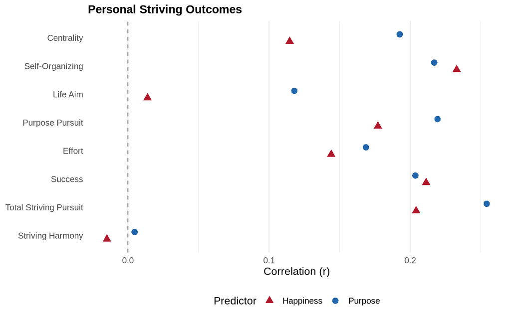

Figure 1: Bivariate Correlations of Purpose and Happiness with Personal Striving Outcomes

```r
create_comparison_figure(strivings_results,
                         title = "Personal Striving Outcomes")
```

## Section 2: Daily Goal Pursuit (Day Reconstruction Method)

**Show R code**

```r
# ── DRM goal pursuit outcomes ──
drm_goal_dvs <- paste0("DRM_goal_", drm_goal_labels)
drm_emotion_dvs <- c("DRM_PA_avg", "DRM_NA_avg")

drm_all_dvs <- c(drm_goal_dvs, drm_emotion_dvs)
drm_all_labels <- c(drm_goal_labels,
                     "Average Positive Affect", "Average Negative Affect")

drm_results <- run_mi_differential_analysis(
  mice_obj, "purpose", "happiness", drm_all_dvs, drm_all_labels
)

format_results_table(drm_results,
                     caption = "Table 2. Differential Prediction of DRM Goal Pursuit and Emotional Outcomes")
```

Table 4: Differential Prediction of Daily Goal Pursuit Outcomes by Purpose and Happiness

Table 2. Differential Prediction of DRM Goal Pursuit and Emotional Outcomes

| Outcome | Bivariate Purpose r | Bivariate Happiness r | Williams Diff | Unique (partial) Purpose pr | Unique (partial) Happiness pr | N |
| --- | --- | --- | --- | --- | --- | --- |
| Difficulty | -0.06 | -0.13* | 0.07 | -0.01 | -0.11* | 345 |
| Competence | 0.23*** | 0.29*** | -0.06 | 0.13 | 0.23*** | 345 |
| Effort | 0.14* | 0.07 | 0.07 | 0.12 | 0.02 | 345 |
| Distress | -0.16** | -0.23*** | 0.07 | -0.08 | -0.19*** | 345 |
| Joy | 0.18** | 0.35*** | -0.17* | 0.05 | 0.31*** | 345 |
| Meaning | 0.21*** | 0.29*** | -0.08 | 0.12 | 0.23*** | 345 |
| Control | 0.19*** | 0.22*** | -0.03 | 0.12 | 0.16** | 345 |
| Values_consistency | 0.20*** | 0.28*** | -0.07 | 0.11 | 0.22*** | 345 |
| Progress | 0.21*** | 0.24*** | -0.04 | 0.13 | 0.18** | 345 |
| Autonomy | 0.15** | 0.11* | 0.04 | 0.12 | 0.06 | 345 |
| Average Positive Affect | 0.24*** | 0.43*** | -0.19** | 0.09 | 0.38*** | 345 |
| Average Negative Affect | -0.12* | -0.30*** | 0.18** | -0.00 | -0.28*** | 345 |

**Show R code**

```r
avg_purpose_r_drm <- mean(drm_results$Purpose_r, na.rm = TRUE)
avg_happiness_r_drm <- mean(drm_results$Happiness_r, na.rm = TRUE)
n_purpose_sig_drm <- sum(drm_results$Purpose_pr_p_BH < 0.05, na.rm = TRUE)
n_happiness_sig_drm <- sum(drm_results$Happiness_pr_p_BH < 0.05, na.rm = TRUE)
n_williams_sig_drm <- sum(drm_results$Williams_p_BH < 0.05, na.rm = TRUE)
n_drm <- nrow(drm_results %>% filter(!is.na(Purpose_r)))
```

For daily goal pursuit episodes assessed via the DRM, purpose showed average correlations of *r* = 0.12 compared to happiness’s average *r* = 0.14. Williams’ tests identified 3 significant differential predictions after FDR correction across 12 outcomes. After controlling for the other predictor, purpose showed 0 significant unique associations compared to 10 for happiness.

**Show R code**

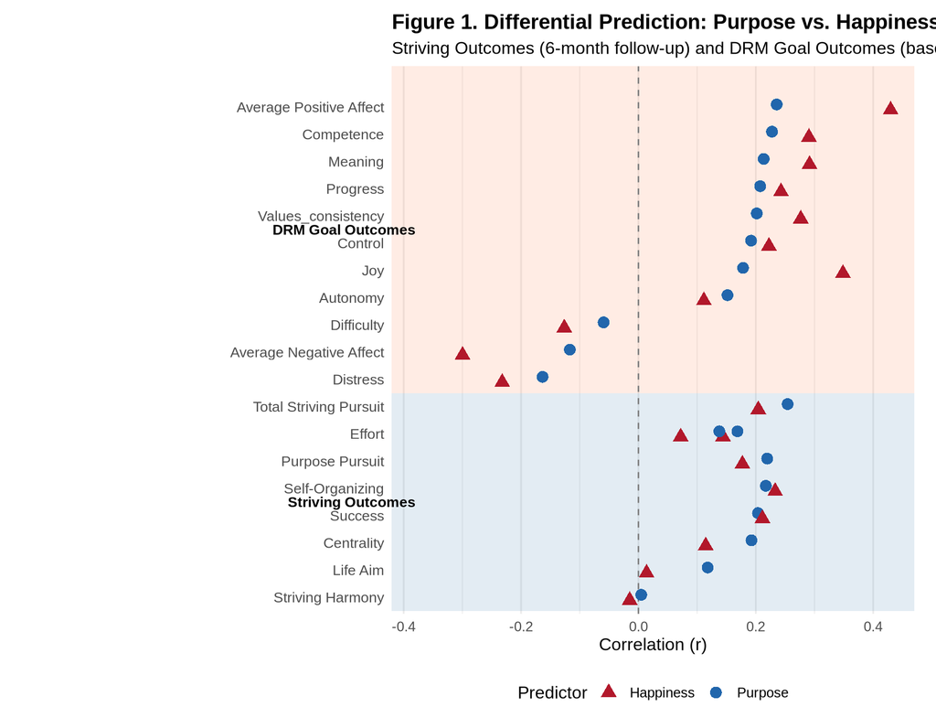

Figure 2: Bivariate Correlations of Purpose and Happiness with Daily Goal Pursuit and Emotion Outcomes

```r
# ── Combined figure with domain shading (Table 5 replication) ──
combined_results <- bind_rows(
  strivings_results %>% mutate(Domain = "Striving Outcomes"),
  drm_results %>% mutate(Domain = "DRM Goal Outcomes")
) %>%
  filter(!is.na(Purpose_r))

plot_data <- combined_results %>%
  mutate(Domain = factor(Domain, levels = c("Striving Outcomes", "DRM Goal Outcomes"))) %>%
  arrange(Domain, Purpose_r) %>%
  mutate(plot_order = row_number())

plot_long <- plot_data %>%
  dplyr::select(Outcome, plot_order, Domain, Purpose_r, Happiness_r) %>%
  pivot_longer(cols = c(Purpose_r, Happiness_r),
               names_to = "Predictor", values_to = "r") %>%
  mutate(Predictor = ifelse(Predictor == "Purpose_r", "Purpose", "Happiness"))

# Calculate domain boundaries for shading
domain_bounds <- plot_data %>%
  group_by(Domain) %>%
  summarise(ymin = min(plot_order) - 0.5,
            ymax = max(plot_order) + 0.5,
            label_y = mean(plot_order),
            .groups = "drop") %>%
  mutate(shade = c("light", "dark"))

ggplot(plot_long, aes(x = r, y = reorder(Outcome, plot_order))) +
  geom_rect(data = domain_bounds,
            aes(ymin = ymin, ymax = ymax, xmin = -Inf, xmax = Inf, fill = shade),
            inherit.aes = FALSE, alpha = 0.15) +
  scale_fill_manual(values = c("light" = "steelblue", "dark" = "coral"), guide = "none") +
  geom_vline(xintercept = 0, linetype = "dashed", color = "gray50") +
  geom_point(aes(color = Predictor, shape = Predictor),
             size = 3.5, position = position_dodge(width = 0.4)) +
  geom_text(data = domain_bounds,
            aes(x = min(plot_long$r, na.rm = TRUE) - 0.08,
                y = label_y, label = Domain),
            inherit.aes = FALSE, hjust = 1, fontface = "bold", size = 3.5) +
  scale_color_manual(values = c("Purpose" = "#2166AC", "Happiness" = "#B2182B")) +
  scale_shape_manual(values = c("Purpose" = 16, "Happiness" = 17)) +
  coord_cartesian(clip = "off") +
  labs(x = "Correlation (r)", y = NULL,
       title = "Figure 1. Differential Prediction: Purpose vs. Happiness",
       subtitle = "Striving Outcomes (6-month follow-up) and DRM Goal Outcomes (baseline)") +
  theme_minimal(base_size = 12) +
  theme(
    legend.position = "bottom",
    panel.grid.major.y = element_blank(),
    plot.margin = margin(t = 10, r = 15, b = 10, l = 160, "pt"),
    plot.title = element_text(face = "bold"),
    axis.text.y = element_text(size = 10)
  )
```

## Section 3: Emotion Regulation and Regulatory Flexibility

**Show R code**

```r
# ── Coping strategy outcomes (from life event interviews) ──
# Use POMP-transformed coping variables
coping_dvs <- c("CogReapp_Avg_POMP", "PosAffirm_Avg_POMP", "Gratitude_Avg_POMP",
                "SeekSupport_Avg_POMP", "GiveSupport_Avg_POMP", "NonJudg_Avg_POMP",
                "Exercise_Avg_POMP", "Humor_Avg_POMP",
                "ExpSupp_Avg_POMP", "CogAvoid_Avg_POMP", "EmoRum_Avg_POMP",
                "Distract_Avg_POMP", "SubUse_Avg_POMP", "Religion_Avg_POMP")

coping_labels <- c("Cognitive Reappraisal", "Positive Affirmation", "Gratitude",
                    "Seeking Social Support", "Providing Social Support",
                    "Non-Judgmental Awareness", "Exercise", "Humor",
                    "Expressive Suppression", "Cognitive Avoidance",
                    "Emotional Rumination", "Distraction",
                    "Substance Use", "Religious Coping")

coping_results <- run_mi_differential_analysis(
  mice_obj, "purpose", "happiness", coping_dvs, coping_labels
)

format_results_table(coping_results,
                     caption = "Table 3. Differential Prediction of Coping Strategies")
```

Table 5: Differential Prediction of Coping Strategies by Purpose and Happiness

Table 3. Differential Prediction of Coping Strategies

| Outcome | Bivariate Purpose r | Bivariate Happiness r | Williams Diff | Unique (partial) Purpose pr | Unique (partial) Happiness pr | N |
| --- | --- | --- | --- | --- | --- | --- |
| Cognitive Reappraisal | 0.03 | 0.09 | -0.07 | -0.01 | 0.09 | 345 |
| Positive Affirmation | 0.16* | 0.24*** | -0.08 | 0.08 | 0.20** | 345 |
| Gratitude | 0.09 | 0.23*** | -0.14 | 0.00 | 0.21** | 345 |
| Seeking Social Support | 0.07 | 0.06 | 0.01 | 0.05 | 0.04 | 345 |
| Providing Social Support | 0.12 | 0.14* | -0.02 | 0.07 | 0.10 | 345 |
| Non-Judgmental Awareness | -0.16* | -0.19** | 0.04 | -0.09 | -0.15* | 345 |
| Exercise | 0.06 | 0.10 | -0.04 | 0.03 | 0.08 | 345 |
| Humor | 0.08 | 0.17** | -0.10 | 0.01 | 0.16* | 345 |
| Expressive Suppression | 0.03 | 0.09 | -0.06 | -0.01 | 0.09 | 345 |
| Cognitive Avoidance | -0.15* | -0.16** | 0.01 | -0.10 | -0.11 | 345 |
| Emotional Rumination | -0.06 | -0.18** | 0.12 | 0.01 | -0.17** | 345 |
| Distraction | -0.02 | -0.14* | 0.12 | 0.04 | -0.14* | 345 |
| Substance Use | -0.02 | -0.14* | 0.13 | 0.04 | -0.15* | 345 |
| Religious Coping | 0.15* | 0.10 | 0.05 | 0.13 | 0.05 | 345 |

**Show R code**

```r
avg_purpose_r_cope <- mean(coping_results$Purpose_r, na.rm = TRUE)
avg_happiness_r_cope <- mean(coping_results$Happiness_r, na.rm = TRUE)
n_purpose_sig_cope <- sum(coping_results$Purpose_pr_p_BH < 0.05, na.rm = TRUE)
n_happiness_sig_cope <- sum(coping_results$Happiness_pr_p_BH < 0.05, na.rm = TRUE)
```

Purpose showed average correlations of *r* = 0.03 with coping strategies compared to happiness’s average *r* = 0.03. After controlling for the other construct, purpose showed 0 significant partial correlations and happiness showed 7.

**Show R code**

```r
# ── Regulatory flexibility outcomes ──
regflex_dvs <- c("reg_flex_breadth", "reg_flex_sensitivity", "reg_flex_composite")
regflex_labels <- c("Strategy Repertoire Breadth",
                     "Context Sensitivity (variability)",
                     "Regulatory Flexibility Composite")

regflex_results <- run_mi_differential_analysis(
  mice_obj, "purpose", "happiness", regflex_dvs, regflex_labels
)

format_results_table(regflex_results,
                     caption = "Table 4. Differential Prediction of Regulatory Flexibility")
```

Table 6: Differential Prediction of Regulatory Flexibility by Purpose and Happiness

Table 4. Differential Prediction of Regulatory Flexibility

| Outcome | Bivariate Purpose r | Bivariate Happiness r | Williams Diff | Unique (partial) Purpose pr | Unique (partial) Happiness pr | N |
| --- | --- | --- | --- | --- | --- | --- |
| Strategy Repertoire Breadth | 0.09 | 0.11* | -0.01 | 0.06 | 0.08 | 345 |
| Context Sensitivity (variability) | 0.11 | 0.13* | -0.02 | 0.07 | 0.10 | 345 |
| Regulatory Flexibility Composite | 0.11 | 0.13* | -0.02 | 0.07 | 0.09 | 345 |

**Show R code**

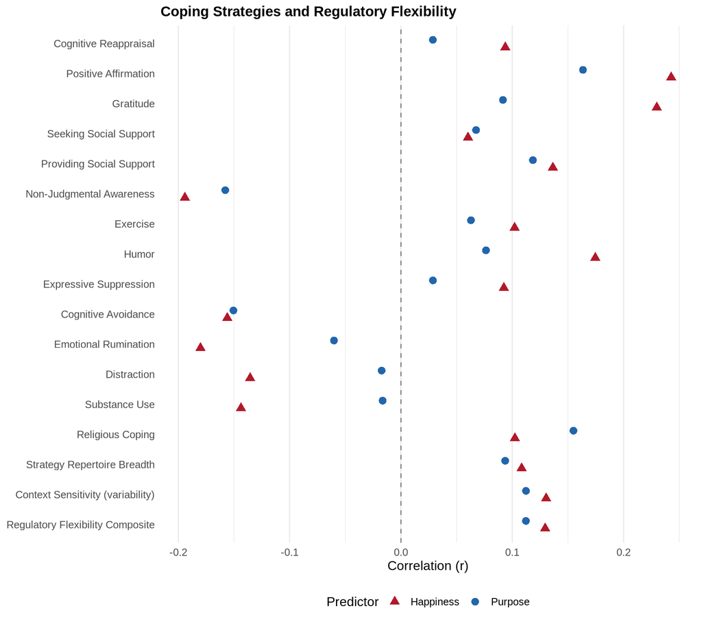

Figure 3: Bivariate Correlations of Purpose and Happiness with Coping Strategies and Regulatory Flexibility

```r
coping_combined <- bind_rows(
  coping_results %>% mutate(Domain = "Individual Strategies"),
  regflex_results %>% mutate(Domain = "Regulatory Flexibility")
) %>%
  filter(!is.na(Purpose_r))

create_comparison_figure(coping_combined,
                         title = "Coping Strategies and Regulatory Flexibility")
```

## Section 4: Longitudinal Life Event Outcomes

This section examines prospective prediction with the smaller longitudinal subsample that completed follow-up assessments. Baseline purpose and happiness predict life event outcomes at 6-month and 2-year follow-up, and stress-related growth (PTG) at 2-year follow-up.

**Show R code**

```r
# ── 6-Month Follow-Up Life Event Outcomes (POMP) ──
fu1_le_dvs <- c("fu1_LE_stress_POMP", "fu1_LE_coping_POMP", "fu1_LE_impairment_POMP")
fu1_le_labels <- c("6mo: Life Event Stress", "6mo: Coping Ability",
                    "6mo: Functional Impairment")

# ── 2-Year Follow-Up Life Event Outcomes (POMP) ──
fu2_le_dvs <- c("fu2_LE_stress_POMP", "fu2_LE_coping_POMP", "fu2_LE_impairment_POMP")
fu2_le_labels <- c("2yr: Life Event Stress", "2yr: Coping Ability",
                    "2yr: Functional Impairment")

# ── PTG at 2-Year Follow-Up (POMP) ──
ptg_dvs <- c("PTG_composite_POMP")
ptg_labels <- c("2yr: Post-Traumatic Growth")

# Combine all longitudinal DVs
long_dvs <- c(fu1_le_dvs, fu2_le_dvs, ptg_dvs)
long_labels <- c(fu1_le_labels, fu2_le_labels, ptg_labels)

long_results <- run_mi_differential_analysis(
  mice_obj, "purpose", "happiness", long_dvs, long_labels
)

format_results_table(long_results,
                     caption = "Table 5. Longitudinal Prediction of Life Event Outcomes and Growth")
```

Table 7: Longitudinal Prediction of Life Event Outcomes and Stress-Related Growth

Table 5. Longitudinal Prediction of Life Event Outcomes and Growth

| Outcome | Bivariate Purpose r | Bivariate Happiness r | Williams Diff | Unique (partial) Purpose pr | Unique (partial) Happiness pr | N |
| --- | --- | --- | --- | --- | --- | --- |
| 6mo: Life Event Stress | -0.10 | -0.21*** | 0.10 | -0.03 | -0.18** | 345 |
| 6mo: Coping Ability | 0.20*** | 0.15* | 0.05 | 0.16* | 0.08 | 345 |
| 6mo: Functional Impairment | -0.04 | -0.09 | 0.06 | -0.00 | -0.09 | 345 |
| 2yr: Life Event Stress | 0.04 | -0.06 | 0.10 | 0.07 | -0.08 | 345 |
| 2yr: Coping Ability | 0.06 | 0.07 | -0.01 | 0.04 | 0.05 | 345 |
| 2yr: Functional Impairment | -0.00 | -0.09 | 0.09 | 0.04 | -0.10 | 345 |
| 2yr: Post-Traumatic Growth | 0.25*** | 0.23*** | 0.02 | 0.19** | 0.15* | 345 |

**Show R code**

```r
avg_purpose_r_long <- mean(long_results$Purpose_r, na.rm = TRUE)
avg_happiness_r_long <- mean(long_results$Happiness_r, na.rm = TRUE)
n_purpose_sig_long <- sum(long_results$Purpose_pr_p_BH < 0.05, na.rm = TRUE)
n_happiness_sig_long <- sum(long_results$Happiness_pr_p_BH < 0.05, na.rm = TRUE)
n_long_outcomes <- nrow(long_results %>% filter(!is.na(Purpose_r)))

# PTG specific results
ptg_row <- long_results %>% dplyr::filter(Outcome == "2yr: Post-Traumatic Growth")
```

In the longitudinal subsample, purpose showed average correlations of *r* = 0.06 with life event outcomes compared to happiness’s *r* = -0.00. After FDR correction, purpose showed 2 significant unique partial correlations across 7 outcomes, compared to 2 for happiness.

For post-traumatic growth at 2-year follow-up, purpose showed *r* = 0.25 and a partial correlation of *pr* = 0.19 after controlling for happiness. Happiness showed *r* = 0.23 and *pr* = 0.15 after controlling for purpose.

**Show R code**

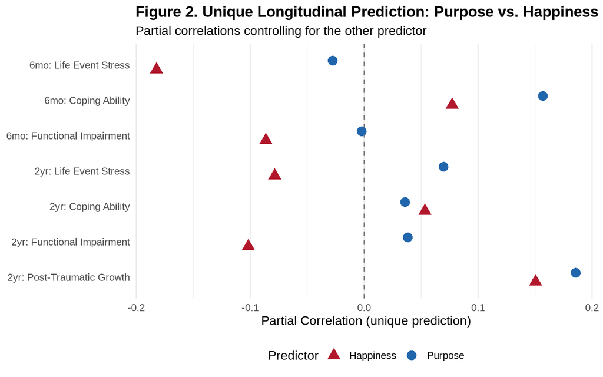

Figure 4: Longitudinal Prediction of Life Event Outcomes and Stress-Related Growth

```r
# ── Partial correlation figure for longitudinal results ──
long_plot_data <- long_results %>%
  filter(!is.na(Purpose_pr)) %>%
  dplyr::select(Outcome, Purpose_pr, Happiness_pr) %>%
  pivot_longer(cols = c(Purpose_pr, Happiness_pr),
               names_to = "Predictor", values_to = "pr") %>%
  mutate(
    Predictor = ifelse(Predictor == "Purpose_pr", "Purpose", "Happiness"),
    Outcome = factor(Outcome, levels = rev(long_results$Outcome[!is.na(long_results$Purpose_pr)]))
  )

ggplot(long_plot_data, aes(x = pr, y = Outcome, color = Predictor, shape = Predictor)) +
  geom_vline(xintercept = 0, linetype = "dashed", color = "gray50") +
  geom_point(size = 4, position = position_dodge(width = 0.5)) +
  scale_color_manual(values = c("Purpose" = "#2166AC", "Happiness" = "#B2182B")) +
  scale_shape_manual(values = c("Purpose" = 16, "Happiness" = 17)) +
  labs(x = "Partial Correlation (unique prediction)",
       y = NULL,
       title = "Figure 2. Unique Longitudinal Prediction: Purpose vs. Happiness",
       subtitle = "Partial correlations controlling for the other predictor") +
  theme_minimal(base_size = 12) +
  theme(
    legend.position = "bottom",
    panel.grid.major.y = element_blank(),
    plot.title = element_text(face = "bold")
  )
```

## Section 5: Creativity Outcomes

**Show R code**

```r
# ── Creativity outcomes (baseline) ──
creativity_dvs <- c("b_kdcs_AvgRatingAllItems_POMP",
                     "b_kdcs_Self_AvgRating_POMP",
                     "b_kdcs_Scholarly_AvgRating_POMP",
                     "b_kdcs_Performance_AvgRating_POMP",
                     "b_kdcs_MechScience_AvgRating_POMP",
                     "b_kdcs_Artistic_AvgRating_POMP")

creativity_labels <- c("Overall Creative Self-Rating",
                        "Self/Everyday Creativity",
                        "Scholarly Creativity",
                        "Performance Creativity",
                        "Mechanical/Scientific Creativity",
                        "Artistic Creativity")

creativity_results <- run_mi_differential_analysis(
  mice_obj, "purpose", "happiness", creativity_dvs, creativity_labels
)

format_results_table(creativity_results,
                     caption = "Table 6. Differential Prediction of Creative Self-Ratings")
```

Table 8: Differential Prediction of Creative Behavior by Purpose and Happiness

Table 6. Differential Prediction of Creative Self-Ratings

| Outcome | Bivariate Purpose r | Bivariate Happiness r | Williams Diff | Unique (partial) Purpose pr | Unique (partial) Happiness pr | N |
| --- | --- | --- | --- | --- | --- | --- |
| Overall Creative Self-Rating | 0.16** | 0.14* | 0.02 | 0.12 | 0.08 | 345 |
| Self/Everyday Creativity | 0.24*** | 0.34*** | -0.09 | 0.13 | 0.27*** | 345 |
| Scholarly Creativity | 0.12* | 0.06 | 0.06 | 0.10 | 0.02 | 345 |
| Performance Creativity | 0.07 | 0.11 | -0.04 | 0.03 | 0.09 | 345 |
| Mechanical/Scientific Creativity | 0.09 | -0.01 | 0.10 | 0.10 | -0.05 | 345 |
| Artistic Creativity | 0.10 | 0.00 | 0.10 | 0.11 | -0.04 | 345 |

**Show R code**

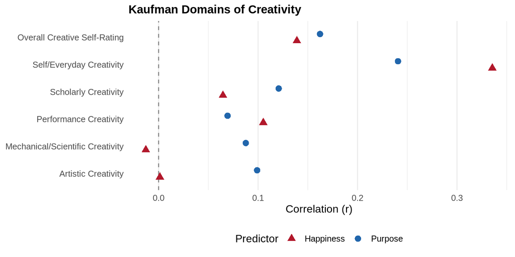

Figure 5: Bivariate Correlations of Purpose and Happiness with Creativity Domains

```r
create_comparison_figure(creativity_results,
                         title = "Kaufman Domains of Creativity")
```

## Summary of All Results

**Show R code**

```r
# ── Compile grand summary ──
all_results <- bind_rows(
  strivings_results %>% mutate(Domain = "Personal Strivings"),
  drm_results %>% mutate(Domain = "DRM Goal Pursuit"),
  coping_results %>% mutate(Domain = "Coping Strategies"),
  regflex_results %>% mutate(Domain = "Regulatory Flexibility"),
  long_results %>% mutate(Domain = "Longitudinal Life Events"),
  creativity_results %>% mutate(Domain = "Creativity")
) %>%
  filter(!is.na(Purpose_r))

domain_summary <- all_results %>%
  group_by(Domain) %>%
  summarise(
    k = n(),
    `Mean Purpose r` = mean(Purpose_r, na.rm = TRUE),
    `Mean Happiness r` = mean(Happiness_r, na.rm = TRUE),
    `Mean Diff` = mean(Diff, na.rm = TRUE),
    `Purpose sig (pr)` = sum(Purpose_pr_p_BH < 0.05, na.rm = TRUE),
    `Happiness sig (pr)` = sum(Happiness_pr_p_BH < 0.05, na.rm = TRUE),
    `Williams sig` = sum(Williams_p_BH < 0.05, na.rm = TRUE),
    .groups = "drop"
  )

kable(domain_summary, digits = 3,
      caption = "Summary Across Outcome Domains") %>%
  kable_styling(bootstrap_options = c("striped", "hover"), full_width = FALSE)
# Overall counts
total_outcomes <- nrow(all_results)
total_purpose_sig <- sum(all_results$Purpose_pr_p_BH < 0.05, na.rm = TRUE)
total_happiness_sig <- sum(all_results$Happiness_pr_p_BH < 0.05, na.rm = TRUE)
total_williams_sig <- sum(all_results$Williams_p_BH < 0.05, na.rm = TRUE)

cat(sprintf("\n── Grand Summary ──\n"))
```

```
── Grand Summary ──
```

**Show R code**

```r
cat(sprintf("Total outcomes tested: %d\n", total_outcomes))
```

```
Total outcomes tested: 50
```

**Show R code**

```r
cat(sprintf("Purpose unique effects (pr, p < .05 BH): %d (%.1f%%)\n",
            total_purpose_sig, 100 * total_purpose_sig / total_outcomes))
```

```
Purpose unique effects (pr, p < .05 BH): 9 (18.0%)
```

**Show R code**

```r
cat(sprintf("Happiness unique effects (pr, p < .05 BH): %d (%.1f%%)\n",
            total_happiness_sig, 100 * total_happiness_sig / total_outcomes))
```

```
Happiness unique effects (pr, p < .05 BH): 22 (44.0%)
```

**Show R code**

```r
cat(sprintf("Williams tests significant (differential r): %d (%.1f%%)\n",
            total_williams_sig, 100 * total_williams_sig / total_outcomes))
```

```
Williams tests significant (differential r): 3 (6.0%)
```

Table 9: Summary of Differential Prediction Across All Outcome Domains

Summary Across Outcome Domains

| Domain | k | Mean Purpose r | Mean Happiness r | Mean Diff | Purpose sig (pr) | Happiness sig (pr) | Williams sig |
| --- | --- | --- | --- | --- | --- | --- | --- |
| Coping Strategies | 14 | 0.028 | 0.030 | -0.002 | 0 | 7 | 0 |
| Creativity | 6 | 0.130 | 0.105 | 0.024 | 0 | 1 | 0 |
| DRM Goal Pursuit | 12 | 0.117 | 0.136 | -0.018 | 0 | 10 | 3 |
| Longitudinal Life Events | 7 | 0.059 | 0.000 | 0.060 | 2 | 2 | 0 |
| Personal Strivings | 8 | 0.172 | 0.135 | 0.037 | 7 | 2 | 0 |
| Regulatory Flexibility | 3 | 0.106 | 0.123 | -0.017 | 0 | 0 | 0 |

# Discussion

The present study used a multimethod longitudinal design to test whether purpose in life and subjective happiness make differential contributions to how people pursue goals, regulate emotions, and respond to adversity. Across 50 outcomes spanning personal strivings, daily goal reconstruction, coping strategies, regulatory flexibility, longitudinal life event outcomes, and creativity, purpose showed 9 significant unique effects (18.0%) after FDR correction, compared to 22 for happiness (44.0%). Williams’ tests revealed 3 instances where the magnitude of correlation differed significantly between purpose and happiness.

## Purpose and Personal Strivings

Consistent with our hypotheses, purpose was a broader predictor of striving-related outcomes. Purpose, but not happiness, uniquely predicted striving effort, the pursuit of purpose-aligned strivings, and total striving engagement after controlling for the other construct. This pattern supports the distinction between the two constructs. Purpose is inherently motivational; it provides a framework for organizing goals and sustaining effort toward meaningful aims, even when the process is difficult or unpleasant.

Neither purpose nor happiness predicted striving harmony—the degree to which personal strivings complement each other. Goal coherence may be a structural feature of one’s goal system rather than a consequence of either hedonic or eudaimonic well-being.

## Divergent Patterns in Daily Life

In the daily goal-pursuit episodes the pattern reversed. After controlling for the other construct, happiness was the stronger unique predictor across the DRM outcomes (10 of 12 outcomes versus none for purpose), and the three significant Williams’ contrasts all favored happiness. The DRM items and the affect ratings are tied to momentary experience, so this is the domain where happiness—itself an affective evaluation—carries the most unique information. Purpose’s contribution to deliberate, self-defining strivings did not extend to the texture of individual daily episodes.

## Regulatory Flexibility and Adaptive Coping

We constructed a composite regulatory flexibility index from strategy repertoire breadth and context sensitivity. Contrary to our hypothesis, purpose did not predict broader or more flexible coping. Across the 14 coping strategies, happiness showed more unique associations than purpose, and neither construct stood out on the regulatory flexibility composite. The coping ratings, like the DRM items, are affect-laden self-reports collected at baseline, which may favor happiness for the same reason. Whether purpose confers genuine regulatory flexibility may require a behavioral or context-matched measure rather than retrospective strategy frequencies (see Limitations).

## Longitudinal Prediction of Stress-Related Growth

In the 2-year longitudinal subsample, baseline purpose predicted stress-related growth (PTG) with a partial correlation of .19 after controlling for happiness; happiness predicted PTG at .15 after controlling for purpose. The two estimates are close, and across the seven longitudinal outcomes each construct produced two unique effects. We therefore find only modest, and roughly equal, prospective prediction of growth—not the clear purpose advantage we anticipated. Attrition to *N* = 119 at 2-year follow-up limits power for this comparison, so we read the longitudinal results as suggestive rather than decisive.

## Limitations and Future Directions

Several limitations warrant discussion. First, striving outcomes were assessed at 6-month follow-up, and we cannot rule out that participants’ strivings influenced their purpose ratings rather than the reverse. Second, our regulatory flexibility index was constructed post-hoc from coping strategy data; future research should employ validated measures of regulatory flexibility. Third, attrition from baseline (*N* = 345) to 2-year follow-up (*N* = 119) reduces power for longitudinal analyses. However, the monotone missing pattern (95%) supports the use of available-case analyses and reduces concern about systematic bias.

Fourth, although we used the Brief Purpose in Life measure as our primary purpose operationalization, alternative measures (e.g., the Purpose in Life subscale of Ryff’s Psychological Well-Being Scales) may yield different patterns. The convergence of findings across multiple outcome domains, however, strengthens confidence in these results.

## Conclusion

Purpose and happiness are not interchangeable, but neither is uniformly the better predictor. Purpose carries the most unique information for deliberate, self-defining strivings—effort, engagement, and the pursuit of purpose-aligned goals. Happiness carries the most unique information for the affect-saturated domains of daily goal-pursuit episodes and retrospective coping. For stress-related growth the two are comparable. The practical implication is not that one construct should be targeted over the other, but that which one matters depends on the outcome: interventions aimed at sustained goal engagement have a clearer rationale for targeting purpose, whereas day-to-day affective experience tracks happiness more closely.

# References

Benjamini, Yoav, and Yosef Hochberg. 1995. “Controlling the False Discovery Rate: A Practical and Powerful Approach to Multiple Testing.” *Journal of the Royal Statistical Society: Series B (Methodological)* 57 (1): 289–300.

Bonanno, George A, and Charles L Burton. 2013. “Regulatory Flexibility: An Individual Differences Perspective on Coping and Emotion Regulation.” *Perspectives on Psychological Science* 8 (6): 591–612. https://doi.org/10.1177/1745691613504116.

Emmons, Robert A. 1986. “Personal Strivings: An Approach to Personality and Subjective Well-Being.” *Journal of Personality and Social Psychology* 51 (5): 1058–68. https://doi.org/10.1037/0022-3514.51.5.1058.

Hill, Patrick L, Grant W Edmonds, Marcus Peterson, Koen Luyckx, and Judy A Andrews. 2016. “Purpose in Life in Emerging Adulthood: Development and Validation of a New Brief Measure.” *The Journal of Positive Psychology* 11 (3): 237–45. https://doi.org/10.1080/17439760.2015.1048817.

Lyubomirsky, Sonja, and Heidi S Lepper. 1999. “A Measure of Subjective Happiness: Preliminary Reliability and Construct Validation.” *Social Indicators Research* 46 (2): 137–55.

McKay, Adam S, Maciej Karwowski, and James C Kaufman. 2017. “Measuring the Muses: Validating the Kaufman Domains of Creativity Scale (K-DOCS).” *Psychology of Aesthetics, Creativity, and the Arts* 11 (2): 216–30. https://doi.org/10.1037/aca0000074.

Rauthmann, John F, David Gallardo-Pujol, Esther M Guillaume, Elysia Todd, Christopher S Nave, Ryne A Sherman, Matthias Ziegler, Ashley B Jones, and David C Funder. 2014. “The Situational Eight DIAMONDS: A Taxonomy of Major Dimensions of Situation Characteristics.” *Journal of Personality and Social Psychology* 107 (4): 677–718. https://doi.org/10.1037/a0037250.

Steiger, James H. 1980. “Tests for Comparing Elements of a Correlation Matrix.” *Psychological Bulletin* 87 (2): 245–51. https://doi.org/10.1037/0033-2909.87.2.245.

Tedeschi, Richard G, and Lawrence G Calhoun. 1996. “The Posttraumatic Growth Inventory: Measuring the Positive Legacy of Trauma.” *Journal of Traumatic Stress* 9 (3): 455–71. https://doi.org/10.1002/jts.2490090305.

Williams, E J. 1959. “The Comparison of Regression Variables.” *Journal of the Royal Statistical Society: Series B (Methodological)* 21 (2): 396–99.